# LPS Sensitivity

Anna L Tyler

February 13, 2024

The purpose of this workflow is to start exploring the LPS sensitivity data and to run cape on it to see if there any informative interactions.

```r
rm(list = ls())

library(here)
```

```r
all.fun <- list.files(here("Code"), full.names = TRUE, pattern = ".R")
for(i in 1:length(all.fun)){source(all.fun[i])}

all.packages <- c("pheatmap", "qtl2", "cluster")
load_libraries(all.packages)

load_latest_cape(here("../../../git_repositories/cape"))
```

[output not shown]

[output not shown]

[output not shown]

[output not shown]

[output not shown]

[output not shown]

[output not shown]

[output not shown]

We need to take the non-numeric phenotypes out of the phenotype file and put them into covariates. I also added ‘NA’ to the na.strings argument in the yaml file.

```r
#if this is the first time through, create a new data directory

mod.data.dir <- here("Data", "qtl2_files_mod")

if(!file.exists(mod.data.dir)){
    #duplicate all files
    file.copy(here("Data", "qtl2_files"), mod.data.dir, recursive = TRUE)

    orig.pheno <- read.csv(here("Data", "qtl2_files", "lps_pheno.csv"))
    orig.covar <- read.csv(here("Data", "qtl2_files", "lps_covar.csv"))

    nonnum.pheno.col <- c("strain", "category")
    num.pheno.col <- setdiff(colnames(orig.pheno), nonnum.pheno.col)
    nonnum.pheno <- cbind(orig.covar, orig.pheno[,nonnum.pheno.col])

    num.pheno <- orig.pheno[,num.pheno.col]

    write.table(num.pheno, here("Data", "qtl2_files_mod", "qtl2_files", "lps_pheno.csv"),
        sep = ",", quote = FALSE, row.names = FALSE)
    write.table(nonnum.pheno, here("Data", "qtl2_files_mod", "qtl2_files", "lps_covar.csv"),
        sep = ",", quote = FALSE, row.names = FALSE)
}
```

```r
#add 'NA' to the na.strings arguments in the yaml file to
#suppress the warning about "NAs introduced by coercion"
lps <- read_cross2(here("Data", "qtl2_files_mod", "qtl2_files", "lps.yaml"))
lps_cape <- qtl2_to_cape(lps)
```

```
## Converting sex to numeric.
## Converting cross_direction to numeric.
## Converting strain to numeric.
## Converting category to numeric.
## Converting genoprobs to array...
```

```r
data_obj <- lps_cape$data_obj
geno_obj <- lps_cape$geno_obj
```

## Body Temperature

Body temperature was measured hourly for seven hours post LPS injection. The following plot shows a heatmap of the temperatures after the injection. There are several patterns. Some temperatures stay fairly steady. Others dip a bit after a few hours, and some really drop in the last couple hours of the experiment. In some animals the temperatures go up initially, and others hold more steady before dropping.

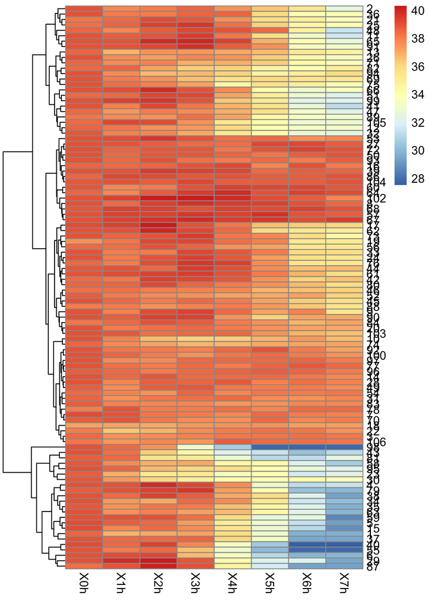

```r
temp.idx <- grep("X", colnames(data_obj$pheno))
temp.label <- gsub("X", "", colnames(data_obj$pheno)[temp.idx])
temp <- data_obj$pheno[,temp.idx]

pheatmap(temp, cluster_cols = FALSE)
```

```r
k = 7
```

We can cluster the tamperature profiles hierarchically to see the different patterns. The following heatmap shows the cluster assignments for 7 clusters.

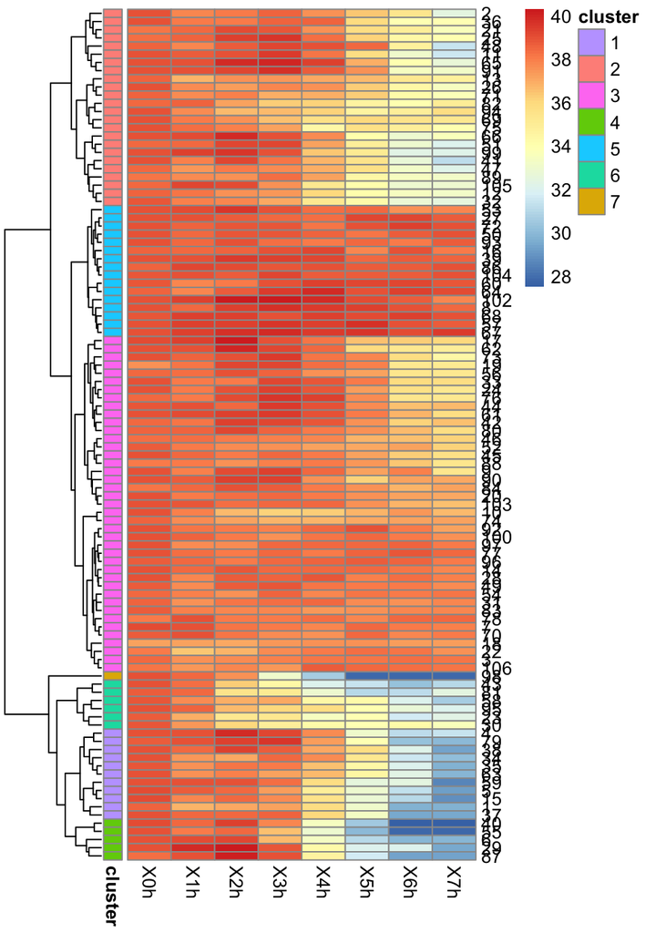

```r
temp_clust <- hclust(dist(temp))
cl <- cutree(temp_clust, k = k)

cl_annot <- data.frame("cluster" = as.factor(cl))
rownames(cl_annot) <- rownames(temp)
pheatmap(temp, annotation_row = cl_annot, cluster_cols = FALSE)
```

If we plot the profiles out for each cluster independently, we can better see the different profiles.

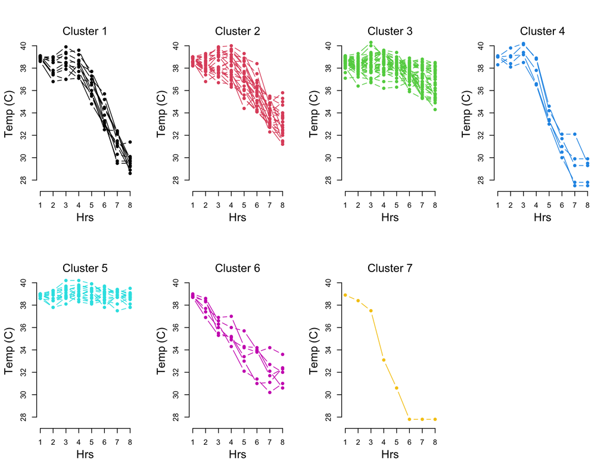

```r
layout.mat <- get.layout.mat(k)
layout(layout.mat)
for(cl.k in 1:k){
    plot.new()
    plot.window(xlim = c(1,ncol(temp)), ylim = c(min(temp),  max(temp)))
    cl.idx <- which(cl == cl.k)
    axis(1);mtext("Hrs", side = 1, line = 2.5)
    axis(2);mtext("Temp (C)", side = 2, line = 2.5)
    mtext(paste("Cluster", cl.k), side = 3)
    for(i in 1:length(cl.idx)){
        points(1:ncol(temp), temp[cl.idx[i],], col = cl[cl.idx[i]], type = "b", pch = 16)
    }
}
```

If we plot the first two principal components of the temperature matrix against each other, we see that the clusters separate along the first principal component, which accounts for 84% of the variation in temperature. This suggests that the first prinicipal component might be a good trait for mapping.

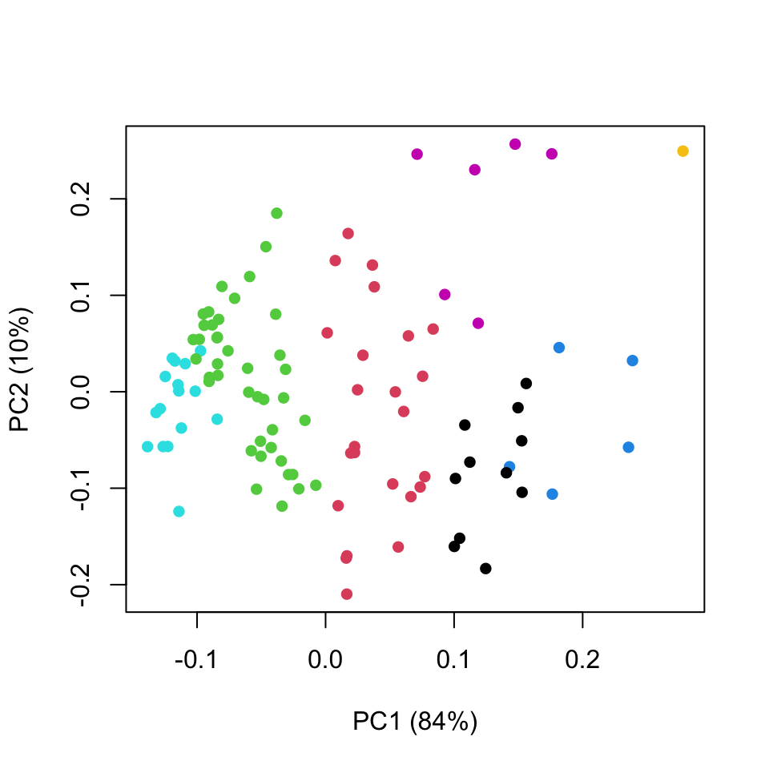

```r
temp.decomp <- plot.decomp(temp, cols = cl)
```

```r
temp.pc <- temp.decomp$u[,1,drop=FALSE]
colnames(temp.pc) <- "Temp_PC1"
rownames(temp.pc) <- rownames(temp)
data_obj$pheno <- cbind(data_obj$pheno, temp.pc)
#boxplot(temp.decomp$u[,1]~cl)
```

The first PC odf the temperature matrix is more heavily weighted on later temperature measurements than on earlier temperature measurements.

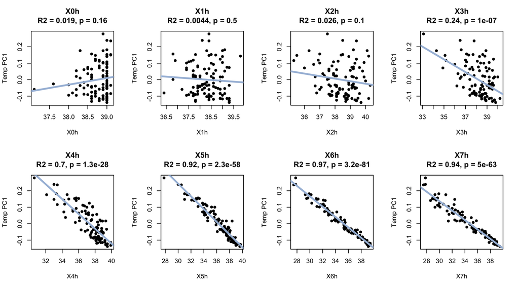

```r
#quartz(width = 9, height = 5)
par(mfrow = c(2,4))
for(i in 1:ncol(temp)){
    plot.with.model(temp[,i], temp.pc, main = colnames(temp)[i], xlab = colnames(temp)[i],
        ylab = "Temp PC1")
}
```

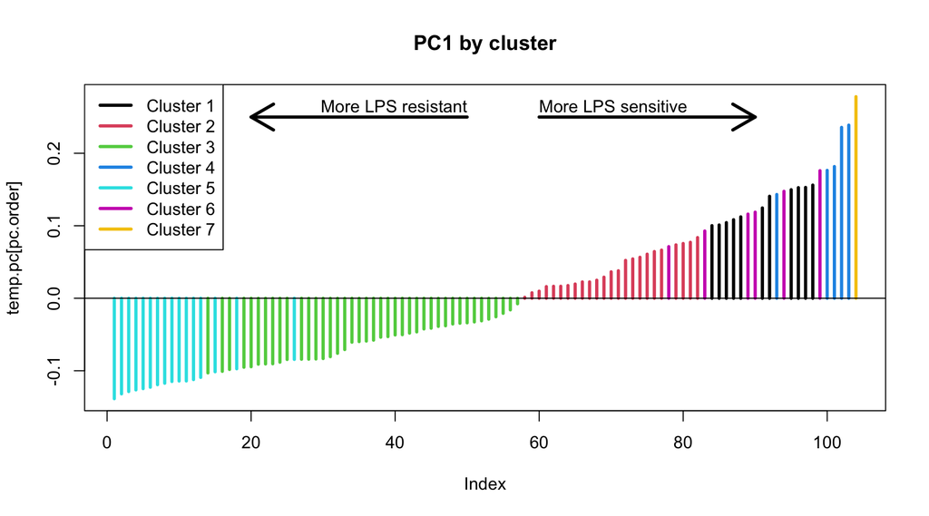

```r
#quartz(width = 9, height = 5.5)
pc.order <- order(temp.pc)
plot(temp.pc[pc.order], type = "h", col = cl[pc.order], lwd = 3,
    main = "PC1 by cluster")
abline(h = 0)
legend("topleft", legend = paste("Cluster", 1:k), lty = 1, lwd = 3, col = 1:k)
arrows(x0 = 50, x1 = 20, y0 = 0.25, lwd = 3)
text(x = 50, y = 0.265, labels = "More LPS resistant", adj = 1)
arrows(x0 = 60, x1 = 90, y0 = 0.25, lwd = 3)
text(x = 60, y = 0.265, labels = "More LPS sensitive", adj = 0)
```

## Trait Correlations

The animals in the upper ranges of the first PC of the temperature matrix, also tend to have higher measurements on in the immune matrix.

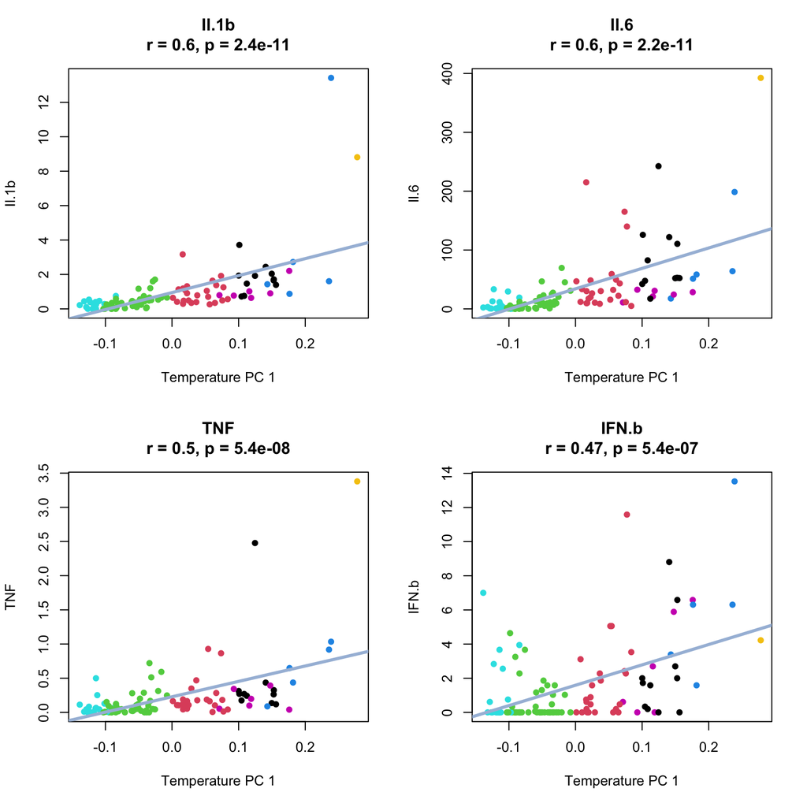

```r
immune <- data_obj$pheno[,c("Il.1b", "Il.6", "TNF", "IFN.b")]
norm.immune <- apply(immune, 2, rankZ)

par(mfrow = c(2,2))
for(i in 1:ncol(norm.immune)){
    plot.with.model(temp.pc, immune[,i], xlab = "Temperature PC 1",
        ylab = colnames(norm.immune)[i],
        main = colnames(norm.immune)[i], report = "cor.test",
        col = cl)
}
```

These correlations extend the range of the values. If we rank Z normalize the values, the correlations are even stronger. There is a floor effect in each of the immune molecules, which is most pronounce in IFN beta. There are animals with a range of temperature profiles that did not have measurable IFN beta.

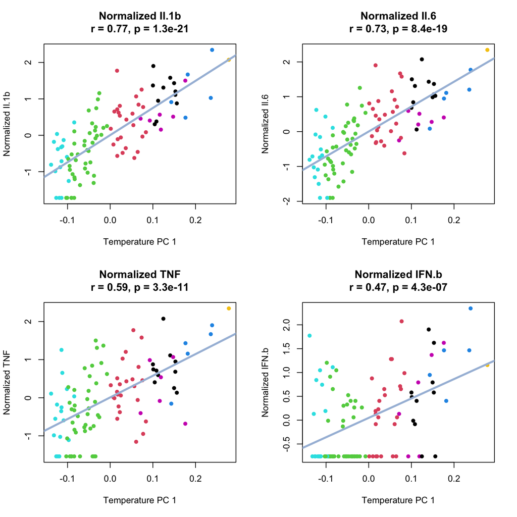

```r
par(mfrow = c(2,2))
for(i in 1:ncol(norm.immune)){
    plot.with.model(temp.pc, norm.immune[,i], xlab = "Temperature PC 1",
        ylab = paste("Normalized", colnames(norm.immune)[i]),
        main = paste("Normalized", colnames(norm.immune)[i]), report = "cor.test",
        col = cl)
}
```

```r
pheatmap(immune, scale = "column")
pairs(immune)
pairs(norm.immune)
pheatmap(cor(norm.immune), display_numbers = TRUE)
pheatmap(cor(immune), display_numbers = TRUE)

boxplot(immune[,4]~cl)
```

[output not shown]

## Individual Trait Mapping

As an initial test, we mapped each of the normalized traits.

The first PC of the temperature matrix has a suggestive QTL on proximal Chr 17. Maybe the MHC locus? IL6 and TNF also map to Chr 17, although the QTLs look more distal. Neither IL1 beta nor IFN beta map anywhere.

```r
genoprobs <- calc_genoprob(lps)
full.pheno <- cbind(temp.pc, norm.immune)
temp.scan <- scan1(genoprobs, full.pheno)
temp.perm <- scan1perm(genoprobs, full.pheno, n_perm = 100)
alpha <- c(0.05, 0.01, 0.1)
sig.level <- summary(temp.perm, alpha = alpha)

for(ph in 1:ncol(full.pheno)){
    cat("###", colnames(full.pheno)[ph], "\n")
   plot(temp.scan, lodcol = ph, map = lps$pmap, ylim = c(0, max(c(max(temp.scan), max(sig.level)*1.05))),
        main = colnames(full.pheno)[ph])
    plot.dim <- par("usr")
    plot.width <- plot.dim[2] - plot.dim[1]
    text.x <- plot.dim[2]-(plot.width*0.007)
    line.stop <- plot.dim[2]-(plot.width*0.04)
    segments(x0 = 0, x1 = line.stop, y0 = sig.level[,ph], lty = 2)
    text(x = text.x, y = sig.level[,ph], labels = alpha, adj = 1)
    cat("\n\n")
}
```

### Temp_PC1

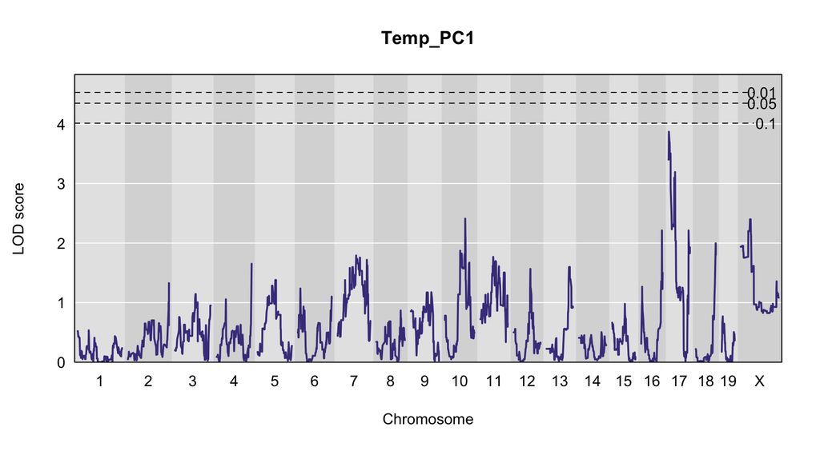

### Il.1b

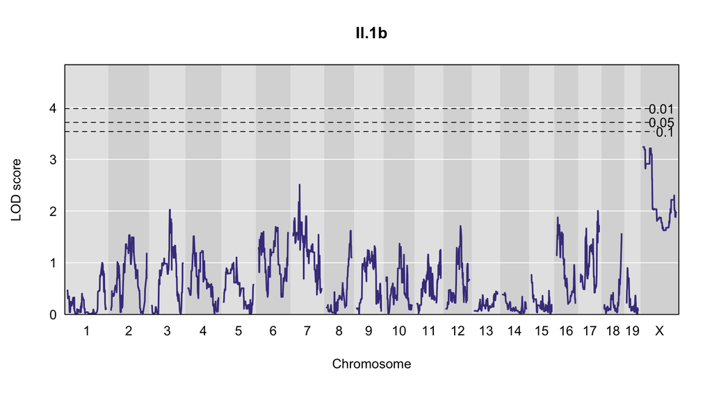

### Il.6

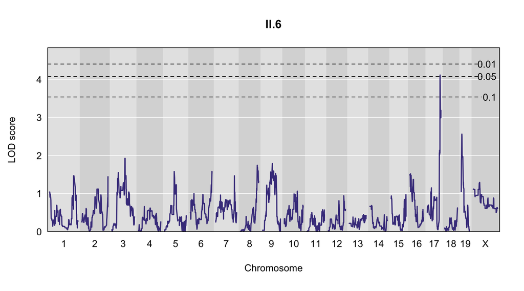

### TNF

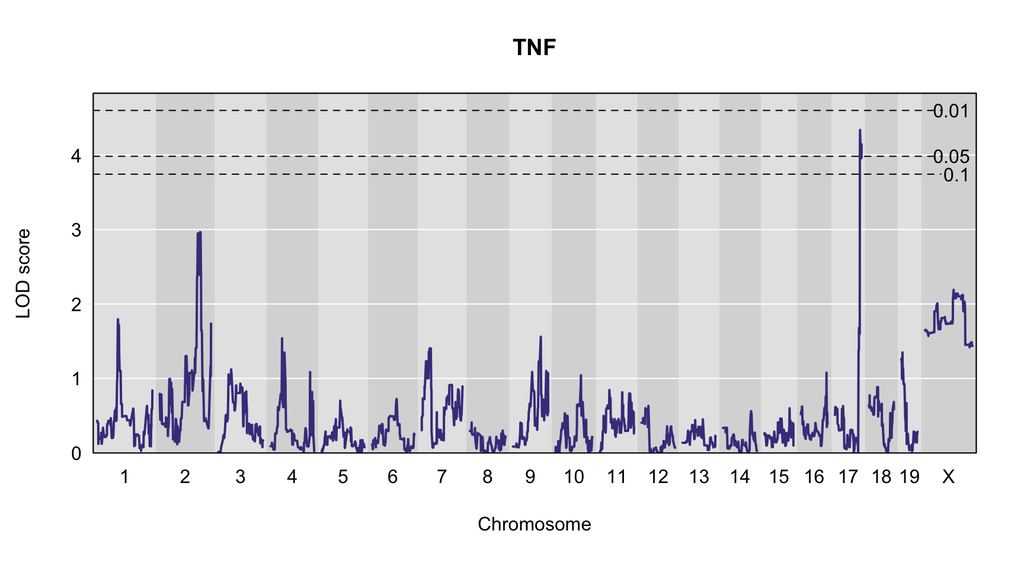

### IFN.b

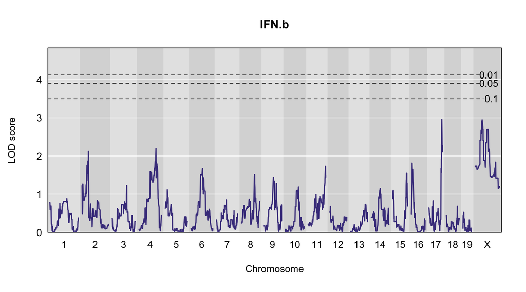

## CAPE

Now we run cape with the combined temperature PC1 and immune molecule matrix. Please see cape_results.html for results from cape.

```r
results_dir <- here("Results", "cape_3ET")
final_obj <- run_cape(data_obj, geno_obj,
    param_file = file.path(results_dir, "0_lps.parameters_0.yml"),
    results_path = results_dir)
```

```
## Removing unused markers...
## Checking for invariant markers.
## Running pheno2covar...
## Plotting svd.pdf...
```

```
## Plotting svd.jpg...
```

```
## Selecting eigentraits...
## Saving data_obj into rds file...
## Running Singlescan...
## Running pairscan...
## Running reparameterization...
## Saving Variant_influences results...
## Saving Variant_Interactions results...
## Plotting Variant_influences.pdf...
```

```
## Plotting Variant_influences.jpg...
```

```
## Plotting Network_Circular.pdf...
```

```
## Plotting Network_Circular.jpg...
```